# LOG708 - Chapter 4 Exercises (4.1 - 4.5)

Alessandro Di Mattia

2026-09-23

Source: [Log708 Compendium — Exercises, Hypothesis Testing](https://home.himolde.no/arntzen/Log708-compendium/exercises/_book/hypothesis-testing.html)

In all tests, use significance level $\alpha = 0.05$ unless otherwise specified.

## Exercise 4.1 — Testing the Mean and a Proportion

In a supermarket, the manager tries to forecast and plan operations for the next quarter. One assumption is that the mean spending $\mu$ per customer is 290 NOK. A second assumption is that only 20% of customers pay with cash, while 10% of customers make a cash withdrawal using a bank card. In a sample of 400 customers, the average spending was found to be $\bar{x} = 319$ NOK, with a standard deviation of $S_x = 100$. Also in the sample, 56 of the 400 customers payed with cash.

### a. Test H0: mu = 290 vs H1: mu != 290

Using $\mu = 290$ as above, and $N(0,1)$ as the approximate null distribution for this one-sample t-test:

```r
n <- 400
x_bar <- 319
s_x <- 100

t_obs <- (x_bar - 290) / (s_x / sqrt(n))
t_obs
```

```
## [1] 5.8
```

```r
# two-sided p-value
pval <- 2 * pnorm(-abs(t_obs))
pval
```

```
## [1] 6.631492e-09
```

The observed value is 5.8, and the P-value is practically 0, so we reject $H_0$ at the 0.05 level. Mean spending is very unlikely to be 290 NOK.

### b. Test H0: p = 0.20 vs H1: p != 0.20

Let $p$ be the proportion of customers paying cash.

```r
x <- 56       # number paying cash
n <- 400

phat <- x / n
phat
```

```
## [1] 0.14
```

```r
z_obs <- (phat - 0.20) / sqrt(0.20 * (1 - 0.20) / n)
z_obs
```

```
## [1] -3
```

```r
pval_p <- 2 * pnorm(-abs(z_obs))
pval_p
```

```
## [1] 0.002699796
```

We get $Z_{obs} = -3.0$ and P-value $\approx 0.003$, so we again reject $H_0$. The proportion of cash-paying customers is likely quite a bit lower than the assumed 0.20. We can double check this with R’s built-in test:

```r
prop.test(x, n, p = 0.20, correct = FALSE)
```

```
##
##  1-sample proportions test without continuity correction
##
## data:  x out of n, null probability 0.2
## X-squared = 9, df = 1, p-value = 0.0027
## alternative hypothesis: true p is not equal to 0.2
## 95 percent confidence interval:
##  0.1094096 0.1774392
## sample estimates:
##    p
## 0.14
```

### c. Is the cash balance reasonable?

Suppose 10% of customers make a cash withdrawal, averaging 400 NOK, while (by assumption) 20% pay with cash, averaging 319 NOK. For each withdrawal (-400), there are on average two cash payments (2 * 319 = 638 NOK), so the cash balance should be fine under the original assumptions. Even using the estimated 14% paying cash (instead of the assumed 20%), each -400 withdrawal is countered by 1.4 * 319 = 447 NOK in cash payments, so the balance still looks reasonable.

## Exercise 4.2 — One-Sample Tests, Confidence Intervals and Correlation

Data: `Trip_durations.csv`. Let $\mu_d$ be the (true) mean duration of trips, and $\mu_s$ be the mean distance of trips.

```r
tripdata <- read.csv("Data/Trip_durations.csv")
head(tripdata)
```

```
##   Duration Distance
## 1     12.5     2.74
## 2     33.5    13.60
## 3     33.1    10.99
## 4     37.0    10.31
## 5     18.3     4.93
## 6     29.3     8.15
```

### a. Sample size, mean and standard deviation for Duration

```r
n <- nrow(tripdata)
x_bar <- mean(tripdata$Duration)
s_x <- sd(tripdata$Duration)

# print the three numbers as a vector (just to save space in output)
c(n, x_bar, s_x)
```

```
## [1] 200.000000  24.310500   6.835471
```

### b. Test H0: mu_d = 24 vs H1: mu_d != 24 (without t.test)

The test statistic is
$$T = \frac{\bar{x}
- 24}{S_x / \sqrt{n}}$$
with $N(0,1)$ as the approximate null distribution.

```r
t_obs <- (x_bar - 24) / (s_x / sqrt(n))
t_obs
```

```
## [1] 0.6424039
```

```r
p_value <- 2 * pnorm(-abs(t_obs))
p_value
```

```
## [1] 0.520611
```

The P-value is about 0.52, so with $\alpha = 0.05$ we can **not** reject $H_0$.

### c. Confirm with t.test

```r
durtest1 <- t.test(tripdata$Duration, mu = 24, alternative = "two.sided")
durtest1$statistic
```

```
##         t
## 0.6424039
```

```r
durtest1$p.value
```

```
## [1] 0.5213503
```

We get almost identical values to the manual calculation in b.

### d. Repeat b. and c. for H0: mu_d = 23

```r
t_obs <- (x_bar - 23) / (s_x / sqrt(n))
t_obs
```

```
## [1] 2.711338
```

```r
p_value <- 2 * pnorm(-abs(t_obs))
p_value
```

```
## [1] 0.006701235
```

```r
durtest2 <- t.test(tripdata$Duration, mu = 23, alternative = "two.sided")
durtest2$statistic
```

```
##        t
## 2.711338
```

```r
durtest2$p.value
```

```
## [1] 0.007287267
```

This time the P-value is about 0.007, well below 0.05, so we clearly reject $H_0$ — the opposite conclusion from testing $\mu_d = 24$.

### e. Test whether mu_s > 10 (Distance)

```r
disttest <- t.test(tripdata$Distance, mu = 10, alternative = "greater")
disttest
```

```
##
##  One Sample t-test
##
## data:  tripdata$Distance
## t = 1.9522, df = 199, p-value = 0.02616
## alternative hypothesis: true mean is greater than 10
## 95 percent confidence interval:
##  10.06158      Inf
## sample estimates:
## mean of x
##  10.40115
```

We get $T_{obs} \approx 1.95$ with P-value $\approx 0.026$, which is below 0.05, so we reject $H_0$ and conclude the mean distance is greater than 10 km — although the evidence is relatively weak (the P-value is not much below 0.05).

### f. 95% confidence intervals for mu_d and mu_s

```r
dur_test <- t.test(tripdata$Duration)
dist_test <- t.test(tripdata$Distance)

dur_test$conf.int
```

```
## [1] 23.35737 25.26363
## attr(,"conf.level")
## [1] 0.95
```

```r
dist_test$conf.int
```

```
## [1]  9.995949 10.806351
## attr(,"conf.level")
## [1] 0.95
```

### g. Correlation between Distance and Duration

```r
with(tripdata, cor(Duration, Distance))
```

```
## [1] 0.9461513
```

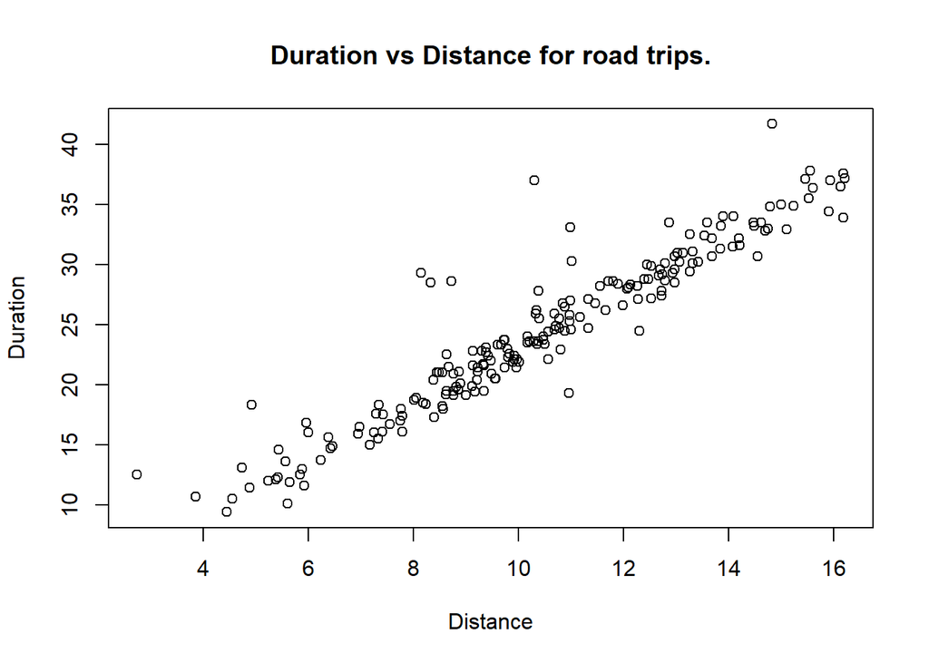

```r
with(tripdata, plot(Distance, Duration,
                    main = "Duration vs Distance for road trips."))
```

The correlation is about 0.95, and the scatterplot shows a strong, clearly positive relationship between the two variables.

## Exercise 4.3 — Comparing Groups (Two-Sample t-tests)

Data: `flat_prices.csv`, with sold flats in Molde, Kristiansund and Ålesund. The `town` variable is encoded 1 = Molde, 2 = Kristiansund, 3 = Ålesund.

```r
flats <- read.csv("Data/flat_prices.csv")
head(flats)
```

```
##   price area rooms standard situated town distcen age rent
## 1  1031  100     3        2        6    1       5  15 2051
## 2  1129  116     3        1        5    1       4  42 2834
## 3  1123  110     3        2        5    1       3  25 2468
## 4   607   59     2        3        5    1       6  25 1940
## 5   858   72     2        3        4    1       1  17 1611
## 6   679   64     2        2        3    1       3  17 2039
```

### a. Mean price in the three towns

```r
with(flats, tapply(price, town, mean))
```

```
##        1        2        3
## 1008.122  949.500 1064.538
```

We see clear differences in average price between the towns.

### b. Boxplot of price by town

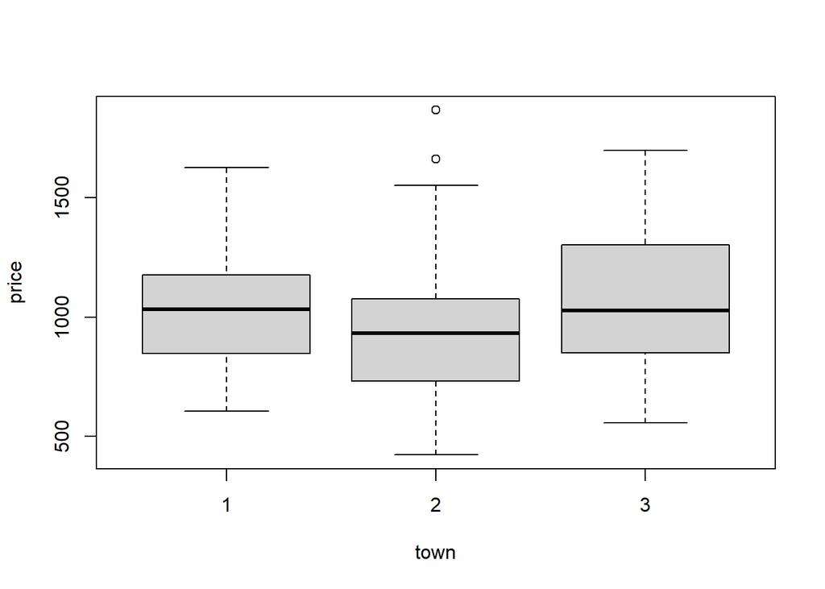

```r
with(flats, boxplot(price ~ town))
```

This shows the same pattern of differences, and also a somewhat wider spread of prices in Ålesund.

### c. Two-sample t-tests: Molde vs Kristiansund, and Kristiansund vs Ålesund

$H_0: \mu_M = \mu_K$ vs $H_1: \mu_M \neq \mu_K$. Since `t.test` needs a grouping variable with only two levels, we first exclude town 3.

```r
flats_MK <- subset(flats, town != 3)
with(flats_MK, t.test(price ~ town))
```

```
##
##  Welch Two Sample t-test
##
## data:  price by town
## t = 1.1339, df = 99.663, p-value = 0.2596
## alternative hypothesis: true difference in means between group 1 and group 2 is not equal to 0
## 95 percent confidence interval:
##  -43.95448 161.19839
## sample estimates:
## mean in group 1 mean in group 2
##        1008.122         949.500
```

The relatively high P-value (about 0.26) means we can not reject $H_0$: no significant nominal price difference between Molde and Kristiansund.

```r
flats_KA <- subset(flats, town != 1)
with(flats_KA, t.test(price ~ town))
```

```
##
##  Welch Two Sample t-test
##
## data:  price by town
## t = -1.9751, df = 82.279, p-value = 0.05161
## alternative hypothesis: true difference in means between group 2 and group 3 is not equal to 0
## 95 percent confidence interval:
##  -230.8975312    0.8206081
## sample estimates:
## mean in group 2 mean in group 3
##         949.500        1064.538
```

The P-value here (about 0.052) is right at the boundary — close to significant, but still not below 0.05, so we do not reject $H_0$.

### d. Mean square meter size in the three towns

```r
with(flats, tapply(area, town, mean))
```

```
##         1         2         3
##  95.92683 100.47143  98.69231
```

The sample flats are, on average, somewhat different in size across towns, with Kristiansund flats being the largest on average.

### e. Correlation between area and price

```r
with(flats, cor(price, area))
```

```
## [1] 0.9503176
```

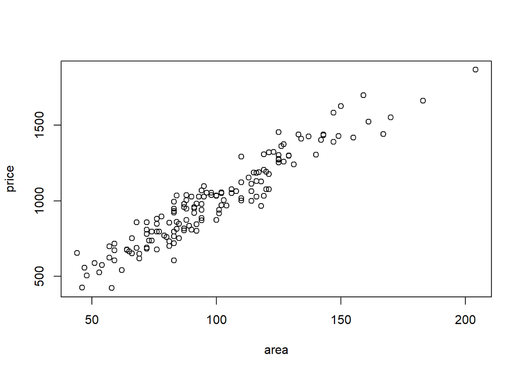

```r
with(flats, plot(area, price))
```

The correlation is strong, about 0.95, and the scatterplot confirms a clear positive relationship, as expected.

### f. New variable: square meter price

```r
flats$sqmprice <- flats$price / flats$area
head(flats)
```

```
##   price area rooms standard situated town distcen age rent  sqmprice
## 1  1031  100     3        2        6    1       5  15 2051 10.310000
## 2  1129  116     3        1        5    1       4  42 2834  9.732759
## 3  1123  110     3        2        5    1       3  25 2468 10.209091
## 4   607   59     2        3        5    1       6  25 1940 10.288136
## 5   858   72     2        3        4    1       1  17 1611 11.916667
## 6   679   64     2        2        3    1       3  17 2039 10.609375
```

### g. Two-sample t-test on square meter price: Molde vs Kristiansund

```r
flats_MK <- subset(flats, town != 3)
with(flats_MK, t.test(sqmprice ~ town))
```

```
##
##  Welch Two Sample t-test
##
## data:  sqmprice by town
## t = 6.6785, df = 75.642, p-value = 3.581e-09
## alternative hypothesis: true difference in means between group 1 and group 2 is not equal to 0
## 95 percent confidence interval:
##  0.7935811 1.4681197
## sample estimates:
## mean in group 1 mean in group 2
##        10.63212         9.50127
```

The P-value is almost 0, far below 0.05, so this time we **reject** $H_0$: square meter prices are significantly higher in Molde than in Kristiansund.

### h. Why do nominal and square-meter price comparisons differ?

When comparing nominal prices, we ignore the fact that, on average, Molde flats are also smaller than Kristiansund flats. Nominal price differences can therefore be misleading, since they mix together a “size effect” and a genuine “price level” effect. Square meter price controls for size, giving a fairer comparison of the underlying price level between towns.

### i. Square meter price: Kristiansund vs Ålesund, and Molde vs Ålesund

```r
flats_KA <- subset(flats, town != 1)
flats_MA <- subset(flats, town != 2)

with(flats_KA, t.test(sqmprice ~ town))
```

```
##
##  Welch Two Sample t-test
##
## data:  sqmprice by town
## t = -8.0705, df = 72.688, p-value = 1.066e-11
## alternative hypothesis: true difference in means between group 2 and group 3 is not equal to 0
## 95 percent confidence interval:
##  -1.695627 -1.023977
## sample estimates:
## mean in group 2 mean in group 3
##         9.50127        10.86107
```

```r
with(flats_MA, t.test(sqmprice ~ town))
```

```
##
##  Welch Two Sample t-test
##
## data:  sqmprice by town
## t = -1.1576, df = 77.974, p-value = 0.2505
## alternative hypothesis: true difference in means between group 1 and group 3 is not equal to 0
## 95 percent confidence interval:
##  -0.6226931  0.1647894
## sample estimates:
## mean in group 1 mean in group 3
##        10.63212        10.86107
```

We reject $H_0$ when comparing Kristiansund and Ålesund (very low P-value), but not when comparing Molde and Ålesund (P-value well above 0.05).

### Bonus: using a factor for town

Converting `town` to a factor with meaningful labels makes the output easier to read:

```r
flats$town <- factor(flats$town, levels = 1:3,
                     labels = c("Molde", "Krsund", "Alesund"))
with(flats, tapply(price, town, mean))
```

```
##    Molde   Krsund  Alesund
## 1008.122  949.500 1064.538
```

## Exercise 4.4 — A Binomial Test

Using `flat_prices.csv` again, let $p$ be the (true) proportion of flats sold that have 2 rooms or less. We test

$$H_0: p = 0.50 \ \text{ vs } \ H_1: p
< 0.50 .$$

```r
flats <- read.csv("Data/flat_prices.csv")

# TRUE/FALSE indicator for "small" flats: fewer than 3 rooms (i.e. <= 2 rooms)
flats$small <- flats$rooms < 3

countsm <- table(flats$small)
countsm
```

```
##
## FALSE  TRUE
##    91    59
```

`countsm` shows the count of small (`rooms < 3`) and large (all others) flats — 59 small and 91 large flats.

```r
binom.test(countsm["TRUE"], sum(countsm), p = 0.50, alternative = "less")
```

```
##
##  Exact binomial test
##
## data:  countsm["TRUE"] and sum(countsm)
## number of successes = 59, number of trials = 150, p-value = 0.005561
## alternative hypothesis: true probability of success is less than 0.5
## 95 percent confidence interval:
##  0.0000000 0.4634347
## sample estimates:
## probability of success
##              0.3933333
```

The P-value is far below 0.05, so we reject $H_0$: the true proportion of small flats is significantly lower than 50%.

## Exercise 4.5 — Checking Normality

Using `flat_prices.csv`, we check whether the selling price of flats appears to follow a normal distribution.

### a. Would you expect prices to be normally distributed?

Prices in a real estate market are typically **not** exactly normal: they are bounded below by 0 and tend to have a longer right tail, since a few large/luxury properties can sell far above the typical price, while very few (if any) sell for much less than the bulk of the market. This kind of right-skew conflicts with the symmetric, unbounded shape of the normal distribution.

### b. Normality test for price

```r
shapiro.test(flats$price)
```

```
##
##  Shapiro-Wilk normality test
##
## data:  flats$price
## W = 0.97897, p-value = 0.02126
```

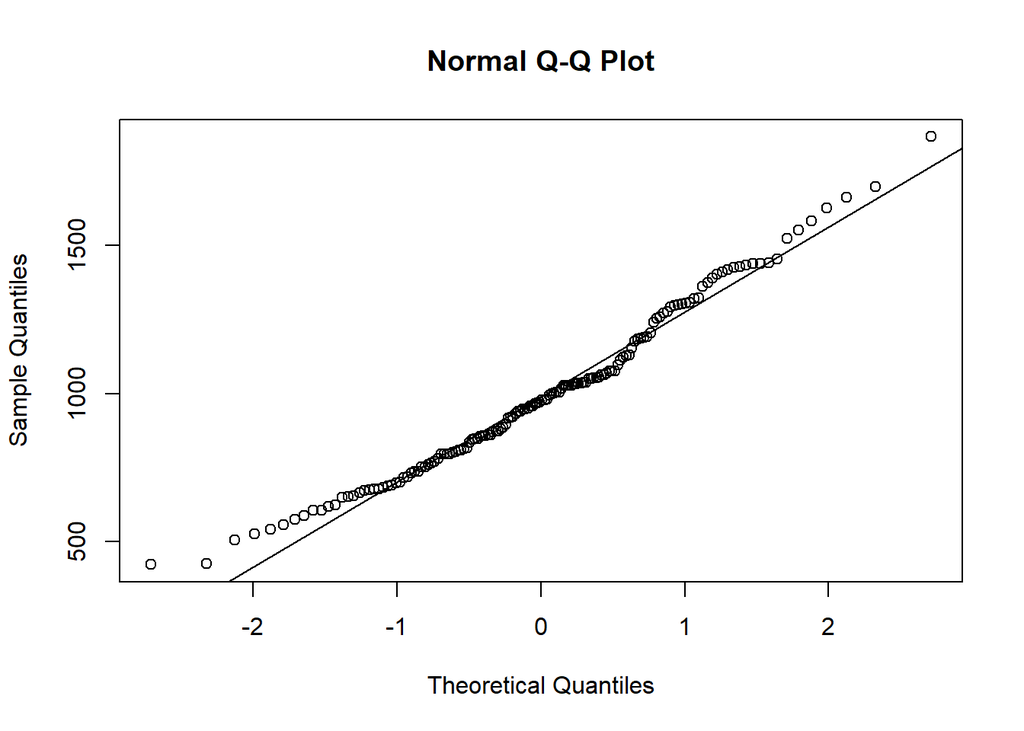

```r
qqnorm(flats$price)
qqline(flats$price)
```

A small `shapiro.test` P-value (below 0.05) indicates a significant departure from normality, and the Q-Q plot typically shows points curving away from the reference line in the tails — consistent with the right-skew expected in a).

### c. Repeat within each town

```r
with(flats, tapply(price, town, shapiro.test))
```

```
## $`1`
##
##  Shapiro-Wilk normality test
##
## data:  X[[i]]
## W = 0.97683, p-value = 0.5577
##
##
## $`2`
##
##  Shapiro-Wilk normality test
##
## data:  X[[i]]
## W = 0.96312, p-value = 0.03732
##
##
## $`3`
##
##  Shapiro-Wilk normality test
##
## data:  X[[i]]
## W = 0.95503, p-value = 0.1215
```

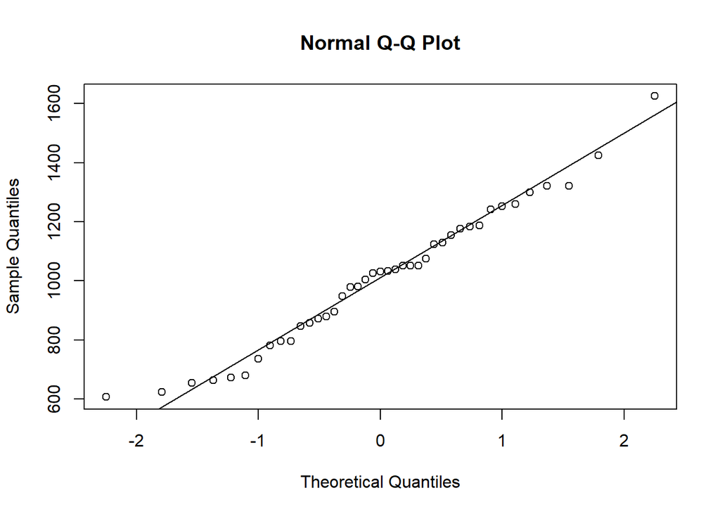

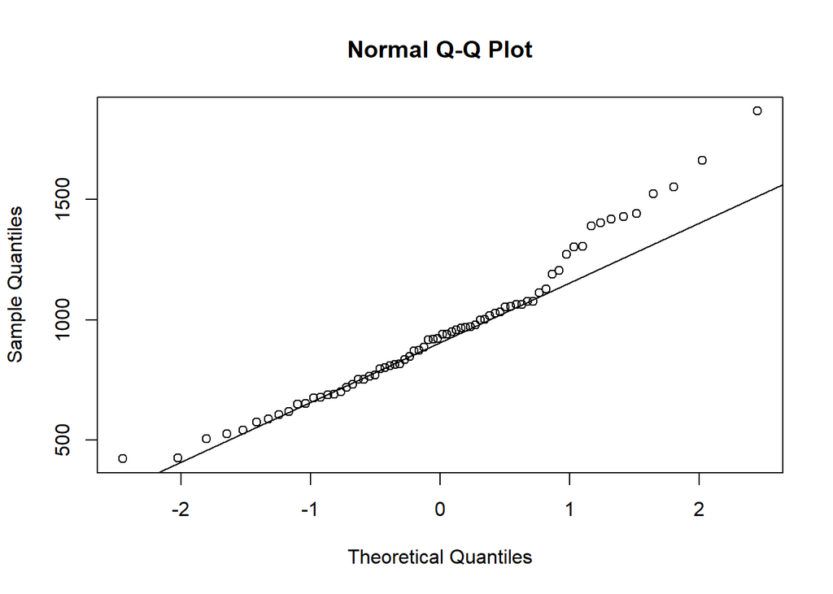

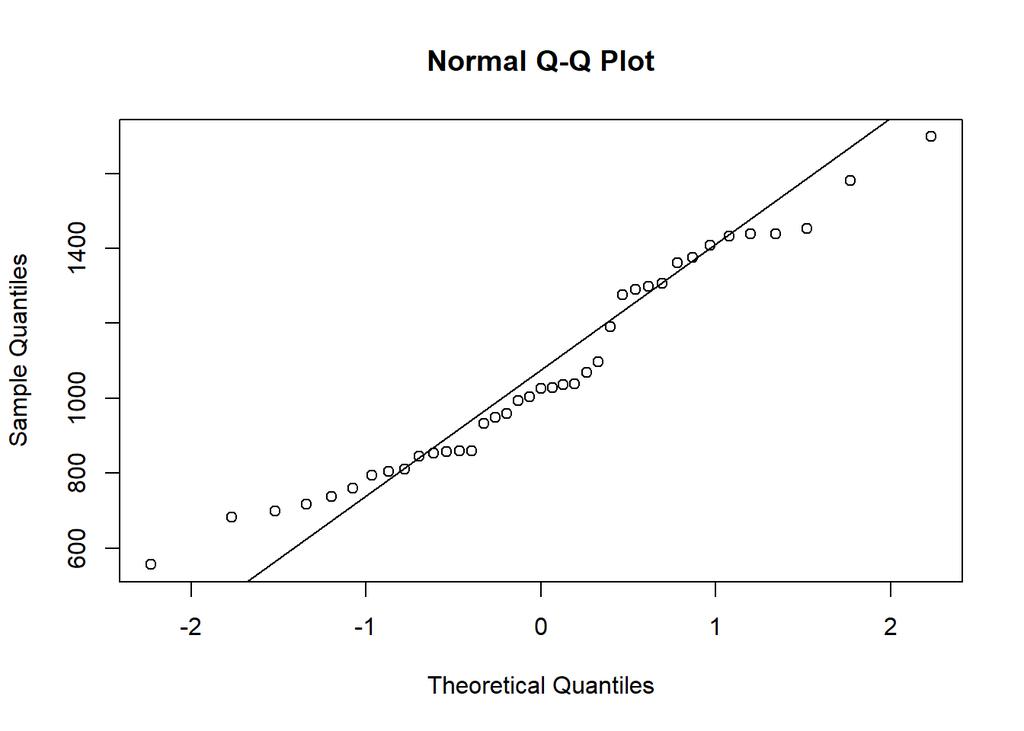

```r
with(flats, tapply(price, town, function(x) { qqnorm(x); qqline(x) }))
```

The combined sample mixes three sub-populations with different mean price levels (see Exercise 4.3a), so pooling them together can make the overall distribution look more skewed/irregular than it does within any single town. Testing normality separately per town removes this “mixture” effect, and each town’s own price distribution is closer to (though still not perfectly) normal.

### d. Are square meter prices normally distributed?

```r
flats$sqmprice <- flats$price / flats$area

shapiro.test(flats$sqmprice)
```

```
##
##  Shapiro-Wilk normality test
##
## data:  flats$sqmprice
## W = 0.97183, p-value = 0.003555
```

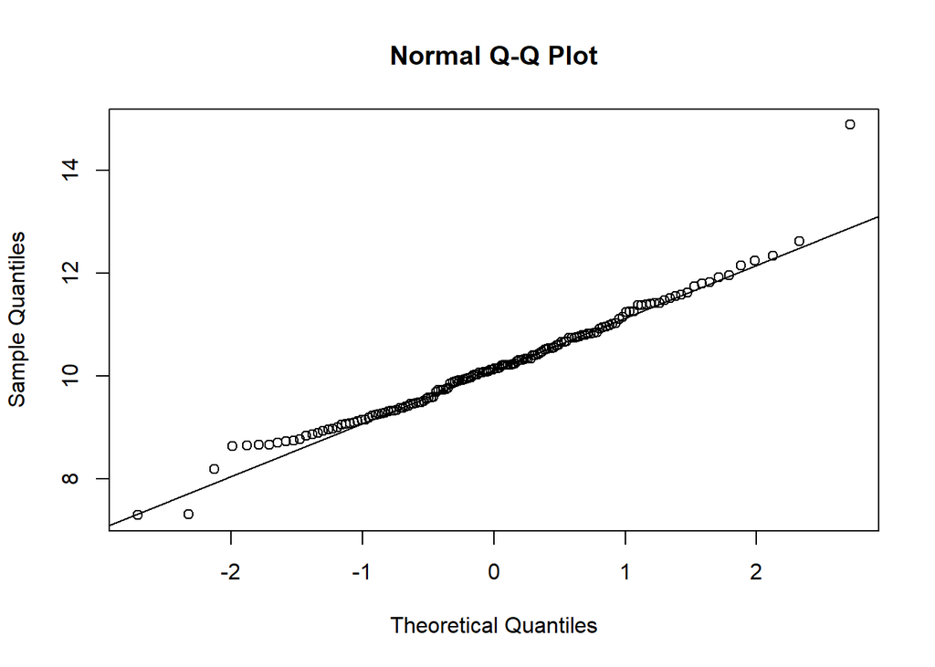

```r
qqnorm(flats$sqmprice)
qqline(flats$sqmprice)
```